# PredictionAssignment

# Background

Using devices such as Jawbone Up, Nike FuelBand, and Fitbit it is now possible to collect a large amount of data about personal activity relatively inexpensively. These type of devices are part of the quantified self movement - a group of enthusiasts who take measurements about themselves regularly to improve their health, to find patterns in their behavior, or because they are tech geeks. One thing that people regularly do is quantify how much of a particular activity they do, but they rarely quantify how well they do it. In this project, your goal will be to use data from accelerometers on the belt, forearm, arm, and dumbell of 6 participants. They were asked to perform barbell lifts correctly and incorrectly in 5 different ways. More information is available from the website here: http://web.archive.org/web/20161224072740/http:/groupware.les.inf.puc-rio.br/har (see the section on the Weight Lifting Exercise Dataset).

Declare library

```r
library(randomForest)
```

```r
library(ggplot2)
library(caret)
```

Download CSV files and save in working directory

```r
testdata<-read.csv("pml-testing.csv",na.strings=c("NA","#DIV/0!",""))
trndata<-read.csv("pml-training.csv",na.strings=c("NA","#DIV/0!",""))
dim(testdata)
```

```
## [1]  20 160
```

```r
dim(trndata)
```

```
## [1] 19622   160
```

data clean as mentioned below

```r
trndata <- trndata[, colSums(is.na(trndata)) == 0]
testdata <- testdata[, colSums(is.na(testdata)) == 0]
trndata <- trndata[,8:60]
table(trndata$classe)
```

```
##
##    A    B    C    D    E
## 5580 3797 3422 3216 3607
```

```r
table(testdata$classe)
```

```
## < table of extent 0 >
```

For predicting training set, now use random forest method to observe the overall performance

```r
trainsection <- createDataPartition(y = trndata$classe, p = 0.6, list = F)
trndata_trn <- trndata[trainsection,]
trndata_test <- trndata[-trainsection,]

randForModel <- randomForest(classe ~ ., data = trndata_trn)
print(randForModel)
```

```
##
## Call:
##  randomForest(formula = classe ~ ., data = trndata_trn)
##                Type of random forest: classification
##                      Number of trees: 500
## No. of variables tried at each split: 7
##
##         OOB estimate of  error rate: 0.63%
## Confusion matrix:
##      A    B    C    D    E  class.error
## A 3346    2    0    0    0 0.0005973716
## B   12 2257   10    0    0 0.0096533567
## C    0    8 2045    1    0 0.0043816943
## D    1    0   32 1895    2 0.0181347150
## E    0    0    1    5 2159 0.0027713626
```

```r
predicteddata <- predict(randForModel,trndata_test)

confusionMatrix(predicteddata, trndata_test$classe)
```

```
## Confusion Matrix and Statistics
##
##           Reference
## Prediction    A    B    C    D    E
##          A 2227    9    0    0    0
##          B    1 1506   18    0    0
##          C    3    3 1350   15    5
##          D    0    0    0 1269    5
##          E    1    0    0    2 1432
##
## Overall Statistics
##
##                Accuracy : 0.9921
##                  95% CI : (0.9899, 0.9939)
##     No Information Rate : 0.2845
##     P-Value [Acc > NIR] : < 2.2e-16
##
##                   Kappa : 0.99
##  Mcnemar's Test P-Value : NA
##
## Statistics by Class:
##
##                      Class: A Class: B Class: C Class: D Class: E
## Sensitivity            0.9978   0.9921   0.9868   0.9868   0.9931
## Specificity            0.9984   0.9970   0.9960   0.9992   0.9995
## Pos Pred Value         0.9960   0.9875   0.9811   0.9961   0.9979
## Neg Pred Value         0.9991   0.9981   0.9972   0.9974   0.9984
## Prevalence             0.2845   0.1935   0.1744   0.1639   0.1838
## Detection Rate         0.2838   0.1919   0.1721   0.1617   0.1825
## Detection Prevalence   0.2850   0.1944   0.1754   0.1624   0.1829
## Balanced Accuracy      0.9981   0.9945   0.9914   0.9930   0.9963
```

```r
#confusionMatrix.train(randForModel)
```

```r
dim(testdata)
```

```
## [1] 20 60
```

```r
dim(trndata)
```

```
## [1] 19622    53
```

```r
testdata2 <- testdata[,8:59]
testdata2$classe <- factor(nrow(testdata2))
levels(testdata2$classe) <- levels(trndata$classe)
testdata2 <- rbind(trndata[1,],testdata2)
testdata2 <- testdata2[2:21,]
testdata2
```

```
##    roll_belt pitch_belt yaw_belt total_accel_belt gyros_belt_x
## 2     123.00      27.00    -4.75               20        -0.50
## 3       1.02       4.87   -88.90                4        -0.06
## 4       0.87       1.82   -88.50                5         0.05
## 5     125.00     -41.60   162.00               17         0.11
## 6       1.35       3.33   -88.60                3         0.03
## 7      -5.92       1.59   -87.70                4         0.10
## 8       1.20       4.44   -87.30                4        -0.06
## 9       0.43       4.15   -88.50                4        -0.18
## 10      0.93       6.72   -93.70                4         0.10
## 11    114.00      22.40   -13.10               18         0.14
## 12      0.92       5.94   -92.70                3         0.05
## 13      1.01       4.96   -87.80                5        -0.10
## 14      0.54       2.45   -88.60                3        -0.06
## 15      0.45       5.02   -87.90                5        -0.05
```

[output cut: 237 more lines]

```r
predictedtestdata <- predict(randForModel,testdata2, type = "class" )
predictedtestdata
```

```
##  2  3  4  5  6  7  8  9 10 11 12 13 14 15 16 17 18 19 20 21
##  B  A  B  A  A  E  D  B  A  A  B  C  B  A  E  E  A  B  B  B
## Levels: A B C D E
```

Print the plot.

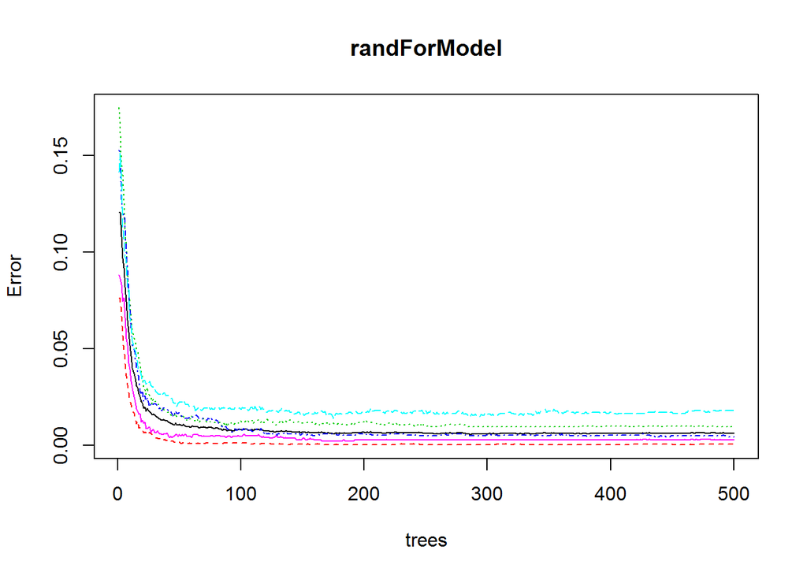

```r
plot(randForModel)
```